# Case Study: Valmax Reality Case

Meag Tessmann

Oct 6-13, 2019

## Load data

```r
# Load data
set.seed(123)
valmax <- read_csv("valmax.csv")
# Inspect data
head(valmax)
```

```
## # A tibble: 6 x 4
##   House `Asking Price` `Selling Price` broker
##   <dbl>          <dbl>           <dbl> <chr>
## 1     1         290000          275000 valmax
## 2     2         315000          314000 valmax
## 3     3         299000          310000 valmax
## 4     4         615000          610000 valmax
## 5     5         345000          345000 valmax
## 6     6         230000          221000 valmax
```

```r
glimpse(valmax)
```

```
## Observations: 79
## Variables: 4
## $ House           <dbl> 1, 2, 3, 4, 5, 6, 7, 8, 9, 10, 11, 12, 13, 14, 1…
## $ `Asking Price`  <dbl> 290000, 315000, 299000, 615000, 345000, 230000, …
## $ `Selling Price` <dbl> 275000, 314000, 310000, 610000, 345000, 221000, …
## $ broker          <chr> "valmax", "valmax", "valmax", "valmax", "valmax"…
```

```r
summary(valmax)
```

```
##      House        Asking Price    Selling Price       broker
##  Min.   : 1.00   Min.   :195000   Min.   :205000   Length:79
##  1st Qu.:10.50   1st Qu.:299000   1st Qu.:288500   Class :character
##  Median :20.00   Median :389000   Median :382000   Mode  :character
##  Mean   :20.51   Mean   :410392   Mean   :402772
##  3rd Qu.:30.00   3rd Qu.:479000   3rd Qu.:473500
##  Max.   :44.00   Max.   :749000   Max.   :735000
```

```r
# no ticks here...
valmax <- clean_names(valmax, 'lower_camel')

# add difference column, clean data types
valmax <- valmax %>%
  mutate(
    difference = askingPrice - sellingPrice,
    broker = factor(broker),
    house = as.integer(house)
  )
```

## Questions

### Q1

Plot the difference between asking vs selling price by broker. Does there appear to be a difference?

Valmax does appear to have a smaller difference than other brokers, with a mean $4653 lower than other brokers and median $6500 lower.

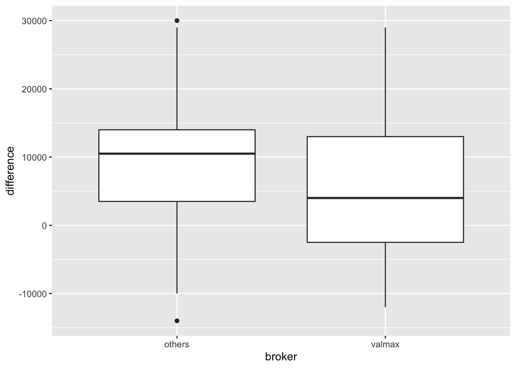

```r
# get an idea of the data
valmax %>%
  group_by(broker) %>%
  ggplot(aes(broker, difference)) +
  geom_boxplot()
```

```r
sum_stats <- valmax %>%
  group_by(broker) %>%
  summarize(
    mean(difference),
    median(difference),
    sd(difference),
    NROW(broker)
  )

sum_stats
```

```
## # A tibble: 2 x 5
##   broker `mean(difference… `median(differe… `sd(difference)` `NROW(broker)`
##   <fct>              <dbl>            <dbl>            <dbl>          <int>
## 1 others             9682.            10500            9986.             44
## 2 valmax             5029.             4000            9960.             35
```

### Q2

Calculate and interpret 95% CIs for mean difference by broker.

While there is a lot of overlap, Valmax does have a lower confidence interval both on the upper and lower ends, suggesting that they do have a slightly lower difference between asking and selling price than other brokers.

```r
# seperate out summary stats to one object per broker
v_stats <- sum_stats %>%
  filter(broker=='valmax')

o_stats <- sum_stats %>%
  filter(broker=='others')

# create function to compute CIs
calc_ci_upper <- function(s_mean, s_sd) {
  s_mean+1.96*(s_sd)
}
calc_ci_lower <- function(s_mean, s_sd) {
  s_mean-1.96*(s_sd)
}

# computer CI upper and lower  bounds for each broker
v_ci_upper <- calc_ci_upper(v_stats$`mean(difference)`, v_stats$`sd(difference)`)
o_ci_upper <- calc_ci_upper(o_stats$`mean(difference)`, o_stats$`sd(difference)`)
v_ci_lower <- calc_ci_lower(v_stats$`mean(difference)`, v_stats$`sd(difference)`)
o_ci_lower <- calc_ci_lower(o_stats$`mean(difference)`, o_stats$`sd(difference)`)

v_ci_lower
```

```
## [1] -14493.37
```

```r
v_ci_upper
```

```
## [1] 24550.51
```

```r
o_ci_lower
```

```
## [1] -9889.776
```

```r
o_ci_upper
```

```
## [1] 29253.41
```

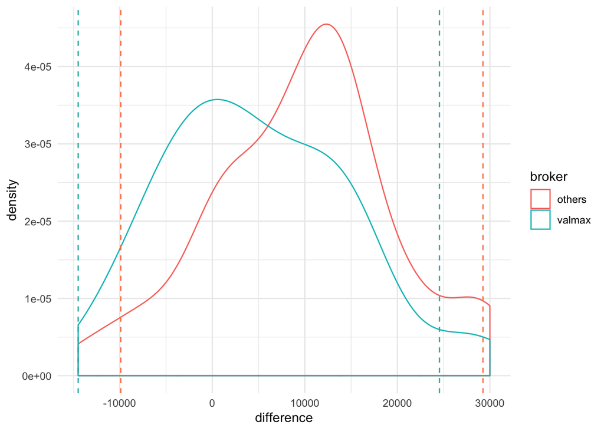

```r
# plot confidence intervals
valmax %>%
  ggplot(aes(difference, color=broker)) +
  geom_density() +
  geom_vline(xintercept = v_ci_lower, lty=2, color='light sea green') +
  geom_vline(xintercept = v_ci_upper, lty=2, color='light sea green') +
  geom_vline(xintercept = o_ci_lower, lty=2, color='coral') +
  geom_vline(xintercept = o_ci_upper, lty=2, color='coral') +
  theme_minimal()
```

### Q3

Compute a t-statistic for mean difference by broker.

```r
# break apart observations by broker

val_obs <- valmax %>%
  filter(broker=="valmax") %>%
  select(difference)
val_obs <- as.vector(val_obs$difference)
oth_obs <- valmax %>%
  filter(broker=='others') %>%
  select(difference)
oth_obs <- as.vector(oth_obs$difference)

# calculate t-statistic, assuming 'others' broker as the null distribution

t_stat <- t.test(val_obs, oth_obs)

t_stat$statistic
```

```
##         t
## -2.060376
```

### Q4

What is the p-value associated with the t-statistic you have computed? Use a 2-tailed test by doubling the p-value obtained with the `pt()` function. (Use the built in t.test function to check your work. Your results should be very close.)

```r
#degrees of freedom
df <- v_stats$`NROW(broker)`-1

#calculate 2-tailed p-value for t-statistic
pt(t_stat$statistic, df)*2
```

```
##          t
## 0.04708078
```

```r
#compare to built in t-test function's p-value calculation
t_stat$p.value
```

```
## [1] 0.04292044
```

### Q5

Are the clients’ complaints justified? Write a paragraph in which you weigh the evidence and argue a position.

We have sufficient evidence (α=.05) to reject the null hypothesis: ‘The mean difference between asking and selling prices when Valmax is the broker is equal to the mean of other brokers’ differences’. There is only a 4.3% probability that there is no difference between Valmax and others’ difference in asking and selling prices. This implies Valmax clients are justified in either or both of two complaints: being advised to set an asking price for their house too low or to buy a house for too much money.